# 14.Linear Regression

Modified

Tu 2023-03-14 16:54

Often when performing data analysis, it is desired to fit experimental data to a particular functional relationship. The fitting of data to a functional relation might be chosen for numerous reasons, but the most common is probably to reduce or eliminate noise from data collected. This curve fitting is formally known as linear regression. The linear in linear regression does not refer to the functional relationship that is to be created but has more to do with the method used to perform the curve fit. Various Linear Algebra techniques are used in such methods. The most prevalent method is known as the least-squares estimation method. Consider the data shown below in Table 1.

Table 1: Sample Data

| x | y |
| --- | --- |
| 1 | 6 |
| 2 | 5 |
| 3 | 7 |
| 4 | 10 |

Say that a linear fit is desired for the data in Table 1. It may be seen that a single line is incapable of passing exactly through all of the points. However, there exists a line that is the closest to all the data points. This line may not pass through any of the points, but it will be the minimum distance from all data points. The length from the data point to this arbitrary line must be determined to construct such a line. These distances are shown in green (the vertical lines between the points and the line) in Figure 1.

Figure 1: Plotted data with linear fit and residuals

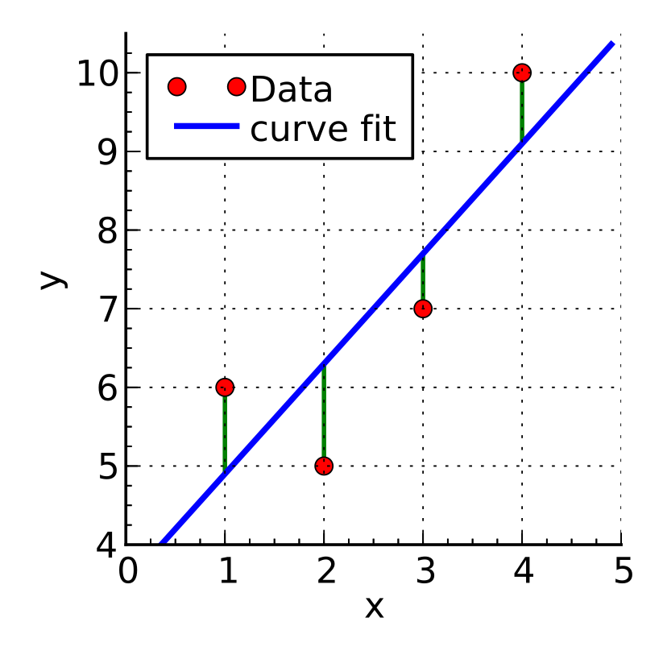

The distance between the points and the plotted line is known as the residuals of the data. The least-squares estimation method aims to find the least total of the squares of the residuals. The reason that the residuals are squared may most clearly be seen by data points 1 and 2. The residuals for the first and second data points are positive and negative, respectively. If just the residuals (not the squares of the residuals) where summed, one can imagine that one residual would cancel out another residual. If the squares of the residuals are summed, this cancellation problem is avoided. Another way to think about it is to say that the least-squares estimation method is not concerned with whether the line is above or below a particular data point. The method is only concerned with the magnitude of the distance away from the data point.

Using the illustration above is useful for getting a general idea of the least-squares estimation method, but putting it to practice is another endeavor. The trouble arises from the fact the exact location of the line is not known. The line is what is desired, and if known, then no problem exists. The method to solve for the line is discussed below.

The first step in the linear least-squares estimation method is to arrange a series of equations using the data collected. The series of equations are shown below.

$$y_1 = \beta_0 + \beta_1 x_1 + \varepsilon_1$$

$$y_2 = \beta_0 + \beta_1 x_2 + \varepsilon_2$$

$$y_3 = \beta_0 + \beta_1 x_3 + \varepsilon_3$$

$$y_4 = \beta_0 + \beta_1 x_4 + \varepsilon_4$$

The $\beta$ terms are the y-intercept ($\beta_0$) and slope ($\beta_1$) of the desired line, respectively. The $x_i$ and $y_i$ terms are the $x$ and $y$ values of each particular data point. The $\varepsilon_i$ is the residual of each data point. Series of equations like the ones shown above may succinctly be written as a linear expression. This linear expression is shown below.

$$Y = X \beta + \varepsilon$$

The terms $Y$, $\beta$, and $ε$ are vectors contains each $y$, $\beta$, and $\varepsilon$ values of the data as shown below.

$$Y = \begin{pmatrix}
y_1 \\
y_2 \\
\vdots \\
y_n
\end{pmatrix}
\beta = \begin{pmatrix}
\beta_1 \\
\beta_2 \\
\vdots \\
\beta_n
\end{pmatrix}
\varepsilon = \begin{pmatrix}
\varepsilon_1 \\
\varepsilon_2 \\
\vdots \\
\varepsilon_n
\end{pmatrix}$$

The $X$ term is arranged differently. The arrangement is shown below.

$$X = \begin{pmatrix}
1 & x_1 \\
1 & x_2 \\
\vdots & \vdots \\
1 & x_n
\end{pmatrix}$$

The next step in the least-squares estimation method is where the estimation arises. If the line being created were to pass through all the data points exactly, the residuals term $\varepsilon$ would be zero. In practice, the residuals are never zero, but if it is assumed that the residuals are close to zero, the following statement may be made.

$$Y \approx X \beta$$

Once this assumption is made, the $\beta$ may be estimated by solving for it. With Linear Algebra, dividing by $X$ is not as straightforward as in regular Algebra. A series of steps must be taken, which results in the expression below.

$$\beta \approx \left( X^T X \right)^{-1} X^T Y$$

The $T$ shown here is not $X$ raised to the $T$ power, but is the [transpose](https://en.wikipedia.org/wiki/Transpose) of $X$. The transpose of a matrix is where a matrix’s rows and columns are swapped. Another thing to mention is the negative one exponent. This exponent is known as the inverse in Linear Algebra. Taking the inverse of a matrix is no simple matter to do by hand, but a computer is very capable of doing so. For this reason, the expression below will be implemented in Python in the following text.

The first step in the implementation of the least-squares estimation method in Python is to import a necessary library called [NumPy](https://numpy.org/). NumPy is a numerical computing package for Python. It is a prevalent package that is used in numerous other scientific packages. The pip command may be used to install NumPy, as seen below.

`pip install numpy`

It may also be done from within Thonny by going to `Tools > Manage Packages` and then searching for NumPy. The install button may then be selected. After installing NumPy, the package must be imported into the script.

```python
import numpy as np
```

The Python implementation of the least-squares method shown here will be designed by using a user-defined function. The function will take two arguments, the $x$ and $y$ data, while returning the coefficients of $\beta$. The function is shown below.

```python
def linear_coeffs(x, y):
    # create a NumPy vector
    Y = np.array(y)

    # Build the X matrix
    X = []
    for x_i in x:
        X.append([1, x_i])

    # create a true NumPy matrix instead of just a list of lists
    X = np.array(X)

    # Calculate B, B = (X'X)^(-1) X' Y
    B = np.matmul(
            np.matmul(
                np.linalg.inv(
                    np.matmul(np.transpose(X), X)
                ), np.transpose(X)
            ), Y
        )

    return B
```

The function may now be used to solve for the coefficients of the line fit. The data in Table 1 are defined as lists below.

```python
x = [1, 2, 3, 4]
y = [6, 5, 7, 10]
```

Using the function is shown below.

```python
print(linear_coeffs(x, y))
```

```
[3.5 1.4]
```

The results shown above are the y-intercept and slope of the line of best fit. That is to say, the line of best is

$$y = 1.4 x + 3.5$$

The result may be double-check using Excel. Doing so shows that the y-intercept and slope are the same. It is important to note that Excel’s method is identical to the technique used here except that Excel is not using Python. Excel uses the least-squares estimation method to find the trendline equation of data. The advantage of implementing the method as a Python function is now the function may be reused for other datasets. For example, say that your thermistor’s calibration data is as shown below.

```python
T = [12.2, 22.1, 57.4]
R = [16640.63, 11136.36, 3081.84]
```

The coefficients of the best linear fit to this data are then

```python
print(linear_coeffs(R, T))
```

```
[ 6.56517026e+01 -3.41085867e-03]
```

The line of best fit for the calibration data is then

$$T = \left( -3.410 \times 10^{-3} \right) R + 65.65$$

The inverse of the line of best fit may quickly be found by

```python
print(linear_coeffs(T, R))
```

```
[18874.49744318  -280.96687382]
```

$$R = -281.0 T + 18874.5$$

## Measure of Fitness

Once a linear fit has been made, the question should be asked, “How good is the fit?” It may be imagined that different regressions will produce slightly different fits, and thus, one fit will likely be better than another. One might try to compare different fits visually and make a judgment that way. However, as an engineer, we should not be satisfied with doing something so haphazard. We must, whenever possible, make our decisions based on quantitative data. The quantitative data that is needed here is known as the coefficient of determination or correlation coefficient. The coefficient of determination of a regression is probably most commonly known as the $R^2$ value of the fit. The $R^2$ value is given by

$$R^2 = 1 - \frac{\Sigma \left( y_i - \hat{y} \right)^2}{\Sigma \left( y_i - \bar{y} \right)^2}$$

where $y_i$ is the dependent data value for each data point, $\bar{y}$ is the average of all the dependent data points, and $\hat{y}$ is the predicted $y$ value for a given independent data value for each data point. $\hat{y}$ is the $y$ value as given by the particular fit of the regression. The coefficient of determination may be calculated as a function in Python. This function is shown below.

```python
import statistics

def coeff_of_determination(xs, ys, f):
    num = 0
    denom = 0
    ybar = statistics.mean(ys)
    for i, x in enumerate(xs):
        num += (ys[i] - f(x))**2
        denom += (ys[i] - ybar)**2
    R2 = 1 - num/denom
    return R2
```

The statistics library must first be imported to use the function defined above. The statistics library is a built-in library, so there is no need to install it separately. The library was installed when Python was installed. The second thing that must be done before the `coeff_of_determination` function may be used is the regression fit must be defined as a Python function. The regression fit from the previous example (the temperature and resistance values) is defined as a Python function below.

```python
def my_fit(x):
    B = linear_coeffs(R, T)
    y = B[0] + B[1]*x
    return y
```

The coefficient of determination may now be determined for this fit. The $R^2$ value of the fit is shown below.

```python
print(coeff_of_determination(R, T, my_fit))
```

```
0.9583382961789092
```

This $R^2$ value may now be used to compare different regression fits to see which one is the best. The $R^2$ may range from -1 to 1, where a value of 1 is considered a “perfect” fit. In practice, a value of 1 may never be achieved because no data set is perfect. Caution must be given to taking this number at face value, though. When comparing $R^2$ values of regressions that take different forms (e.g., $f_1 = \beta_0 + \beta_1 x$ versus $f_2 = \beta_0 + \beta_1 x + \beta_2 x^2$), the regression that has more terms will likely have the higher $R_2$ value. This effect may be clearly be seen using the data set shown Table 2.

Table 2: Recycling Data

| Year | Recycling ($\frac{lbm}{person\ day}$) |
| --- | --- |
| 1960 | 0.16 |
| 1970 | 0.70 |
| 1980 | 0.38 |
| 1990 | 1.04 |
| 2009 | 1.25 |

The data set shows the number of pounds of recycled material per person per day of the given years. A regression fit may be performed where the fit’s general form is linear, quadratic, cubic, and quartic (4th order). The $R^2$ values of the fits are summarized in Table 3.

Table 3: Coefficient of Determination Values

| General Form | $R^2$ |
| --- | --- |
| $\beta_0 + \beta_1 x$ | 0.7830 |
| $\beta_0 + \beta_1 x + \beta_2 x^2$ | 0.7844 |
| $\beta_0 + \beta_1 x + \beta_2 x^2 + \beta_3 x^3$ | 0.7847 |
| $\beta_0 + \beta_1 x + \beta_2 x^2 + \beta_3 x^3 + \beta_4 x^4$ | 1 |

Studying Table 3, one may conclude that the quartic fit is the best. After some thought, the value of 1 for the quartic case should come as no surprise when considering the number of points it takes to draw different polynomials. For a line, it takes two points; for a parabola, it takes three points; For a cubic function, it takes four points; and for a quartic function, it takes five points. Since the data set has five points, the quartic function will be a “perfect” fit. However, this is misleading because the $R^2$ of different forms are being compared. It is essentially comparing an apple to an orange. A new metric must be introduced to compare an apple to an apple. The adjusted coefficient of determination (or $R^2_{adj}$) does just that. The adjusted coefficient of determination considers the number of data points in the data set and the number of coefficients used for the fit. The adjusted coefficient of determination is given by

$$R^2_{adj} = 1 - \left( 1 - R^2 \right) \frac{n - 1}{n - p}$$

where $n$ is the number of data points in the data set, and $p$ is the number of coefficients used in the regression. Table 4 shows the $R^2_{adj}$ for the different forms.

Table 4: Adjusted Coefficient of Determination Values

| General Form | p | $R^2$ | $R^2_{adj}$ |
| --- | --- | --- | --- |
| $\beta_0 + \beta_1 x$ | 2 | 0.7830 | 0.7106 |
| $\beta_0 + \beta_1 x + \beta_2 x^2$ | 3 | 0.7844 | 0.5687 |
| $\beta_0 + \beta_1 x + \beta_2 x^2 + \beta_3 x^3$ | 4 | 0.7847 | 0.1389 |
| $\beta_0 + \beta_1 x + \beta_2 x^2 + \beta_3 x^3 + \beta_4 x^4$ | 5 | 1 | Division by zero! |

From the $R^2_{adj}$ values, it may now clearly be seen which fit is the best, which is the linear fit.